# U.S. Coronavirus Data App

4/4/2020

## U.S. Coronavirus Data App

This app extracts the most recent U.S. coronavirus data from the [NYTimes Github](https://github.com/nytimes/covid-19-data) and displays it at the country, state, and county level according to the user preference.

The information about the last update, total number of cases, deaths, and the link to the NYTimes Github are shown on the first page below the title.

More details information can be found on [github](https://github.com/faridtayari/-Developing-Data-Products).

## U.S. coronavirus

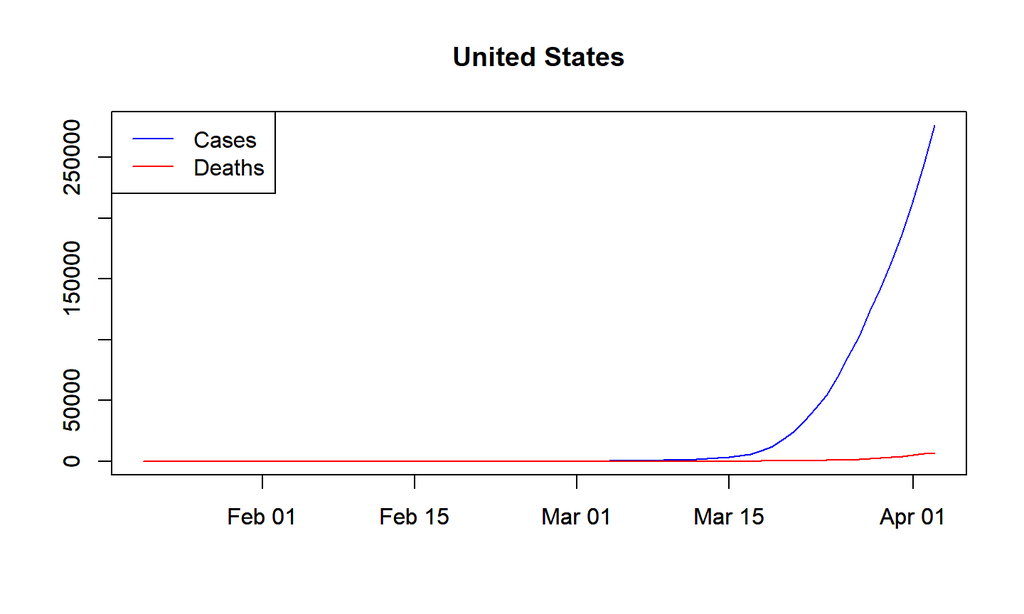

## U.S. Coronavirus Data App

- First, U.S. coronavirus data is plotted.
- Then, state level data is displayed in table and plot formats.
- User can also choose to see the county level data.
- App is accessible on [shinyapps](https://faridtayari.shinyapps.io/FT_App/)

## Coronavirus Data

Coronavirus data data includes:

- Date
- County
- State
- Diagnosed cases
- Deaths

## Plotting the data by the state

- User can choose a State from the list
- Data in the form of timeseries is plotted in the graph
- Data includes diagnosed cases and deaths

## Displaying the data in the table

- User can choose a State from the list
- User can choose to see county level data within the selected state
- The reactive functionality will create a new list that includes only the counties that exist within the selected state in the previous step
- A table is created that includes timeseries of diagnosed cases and deaths only for the selected state and the counties within that state

## Displaying the data

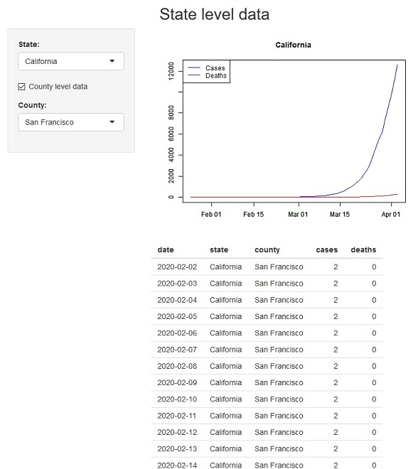

## Displaying the data in the table

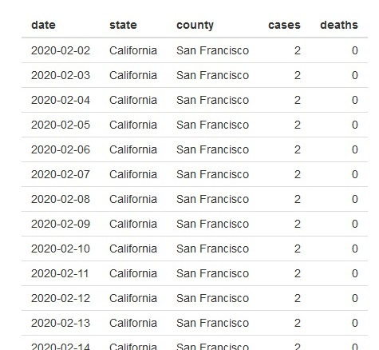